# HCD Simulations Write Up

Audrey Fu Lab

2024-03-07

# 1 Data Simulation

### 1.0.1 Simulating the network

We adopt a top-down approach to simulate hierarchical networks, considering various simulation parameters such as graph sparsity, noise, and the architecture of the super-level graph(s), including small-world, scale-free, and random graph networks (Watts and Strogatz 1998; Barabási and Bonabeau 2003).

In each hierarchy, for fully connected networks, we initiate by simulating $n_{\text{top}}$ top-level nodes, adhering to a directed small-world, random graph, or scale-free network architecture (Watts and Strogatz 1998; Barabási and Bonabeau 2003). In cases where the network is disconnected, we simply simulate $n_{\text{top}}$ disconnected nodes. For networks with three hierarchical layers, we then generate a subnetwork of $n_{\text{middle}}$ nodes from each top-layer node, adhering to the network structure utilized at the top level. If the network is fully connected, we apply a probability $p_\text{between}$ to the nodes from different top-level communities being connected.

The final step in all hierarchies is to generate the nodes in the observed (bottom) layer of the hierarchy. For each top-layer or middle-layer node, we generate a subnetwork of $n_{\text{bottom}}$ nodes under the same subnetwork structure as the previous layers, and we apply a probability $p_\text{between}$ for nodes from different communities to share an edge.

### 1.0.2 Simulating gene expression

Once we simulate a hierarchical graph, we utilize this hierarchy to generate the node-feature matrix, which depicts the expression of $N$ genes across $p$ samples. Here, $N$ denotes the number of nodes in the observed (bottom) layer of the hierarchy, and its range is governed by $a^{\ell+1}<N<a\times b^\ell$, where $\ell$ signifies the number of hierarchical layers.

We simulate the node-feature matrix using the topological order the observed level graph. We start by generating the features of nodes that have no parental input. We refer to these nodes as origin nodes. All origin nodes are simulated from a normal distribution with mean $0$ and standard deviation $\sigma$. All other nodes are simulated from a normal distribution centered at the mean of their parent nodes and with standard deviation $\sigma$.

# 2 Datasets

We consider three sets of hierarchical networks which represent varying difficulty levels for inference:

1. **Complex networks** - used for final simulation assessment - **Table** 4.1 - 4.3 .
2. **Intermediate networks** - used for investigative model tuning and performance assessment - **Table** 4.4 .
3. **Simple networks** - used for code implementation and debugging - **Table** 4.5.

# 3 Application to Intermediate Networks

We apply the HCD method to each network separately using three options for the input graph corresponding to the nodes at the observed layer of the hierarchy:

- The input graph is the true graph
- The input graph is the correlation matrix of the simulated gene expression
- The input graph is the correlation matrix of the simulated gene expression wherein correlations weaker than 0.2 are disregarded and set to zero
- The input graph is the correlation matrix of the simulated gene expression wherein correlations weaker than 0.5 are disregarded and set to zero
- The input graph is the correlation matrix of the simulated gene expression wherein correlations weaker than 0.7 are disregarded and set to zero

We also explore various combinations of weighting the loss function across each of the aforementioned input graphs. In all cases, we ensure that the predicted number of communities in the middle or top levels of the hierarchy aligns with the ground truth of the simulation.

### 3.0.1 Evaluating performance

We evaluate the performance of our HCD method using three graph-based clustering metrics:

1. **homogeneity** evaluates the degree to which each predicted community contains only data points from a single true community, indicating how well the algorithm avoids mixing different groups. Thus, homogenity tends to be high if resolved communities contain only members of the same true community.
2. **completeness** assesses the extent to which all data points that belong to the same true community are correctly assigned to a single predicted community. Thus completeness is always high if all members of the same true communities end up in the same resolved community even if several true communities are allocated together.
3. **NMI** is a weighted average of the previous two metrics.

For each simulation, we configure the number of communities in the middle and upper layers of the hierarchy to match the true count in each layer. Then, we evaluate the community predictions of the Hierarchical Community Detection (HCD) algorithm at these levels against the actual communities using three metrics. As a baseline, we employ the Louvain method, which utilizes hierarchical graph partitioning to maximize modularity, resulting in a single set of resolved communities. These resolved communities may align with the middle, upper, or a combination of both layers in the true hierarchy. Thus, we compute the performance metrics of the communities identified by the Louvain method against the true communities at both the upper and middle levels of the hierarchy.

### 3.0.2 Preliminary findings for applications to intermediate networks

**Figures** 5.1 - 5.2 give a summary of HCD and Louvain performance on predicting the middle and top layer communities across all application settings outlined in the previous section and **Table** 4.6 . **Figure** 5.1 shows the summarized performance across all three subgraph architectures.

Main points:

# 4 Tables

Table 4.1: Summary statistics for all small world networks in the complex networks datset

| Subgraph type | Connect. type | Layers | StDev. | Nodes per layer | Edges per layer | Subgraph prob. | Sample size | Modularity (top) | Avg. node degree top | Avg edges within communities (top) | Avg. edges between communities (top) | Modularity (middle) | Avg. node degree middle | Avg edges within communities (middle) | Avg edges between communities (middle) |
| --- | --- | --- | --- | --- | --- | --- | --- | --- | --- | --- | --- | --- | --- | --- | --- |
| small world | disc | 2 | 0.1 | (10, 63) | (0, 63) | 0.05 | 500 | 0.90 | 1.00 | 6.3 | 0.00 | NA | NA | NA | NA |
| small world | disc | 2 | 0.5 | (10, 63) | (0, 63) | 0.05 | 500 | 0.90 | 1.00 | 6.3 | 0.00 | NA | NA | NA | NA |
| small world | disc | 3 | 0.1 | (10, 63, 1604) | (0, 63, 2011) | 0.05 | 500 | 0.90 | 1.25 | 201.1 | 0.00 | 0.76 | 1.25 | 24.82 | 0.11 |
| small world | disc | 3 | 0.5 | (10, 63, 1604) | (0, 63, 2031) | 0.05 | 500 | 0.90 | 1.27 | 203.1 | 0.00 | 0.76 | 1.27 | 24.97 | 0.12 |
| small world | full | 2 | 0.1 | (10, 63) | (45, 115) | 0.05 | 500 | 0.45 | 1.82 | 6.3 | 0.58 | NA | NA | NA | NA |
| small world | full | 2 | 0.5 | (10, 63) | (45, 109) | 0.05 | 500 | 0.48 | 1.73 | 6.3 | 0.51 | NA | NA | NA | NA |
| small world | full | 3 | 0.1 | (10, 63, 1604) | (45, 114, 1604) | 0.05 | 500 | 0.77 | 1.43 | 199.3 | 3.39 | 0.67 | 1.43 | 24.94 | 0.19 |
| small world | full | 3 | 0.5 | (10, 63, 1604) | (45, 111, 1604) | 0.05 | 500 | 0.77 | 1.44 | 201.3 | 3.28 | 0.66 | 1.44 | 24.87 | 0.19 |

Table 4.2: Summary statistics for all scale free networks in the complex networks datset

| Subgraph type | Connect. type | Layers | StDev. | Nodes per layer | Edges per layer | Subgraph prob. | Sample size | Modularity (top) | Avg. node degree top | Avg edges within communities (top) | Avg. edges between communities (top) | Modularity (middle) | Avg. node degree middle | Avg edges within communities (middle) | Avg edges between communities (middle) |
| --- | --- | --- | --- | --- | --- | --- | --- | --- | --- | --- | --- | --- | --- | --- | --- |
| scale free | disc | 2 | 0.1 | (10, 58) | (0, 74) | 0.05 | 500 | 0.89 | 1.28 | 7.4 | 0.00 | NA | NA | NA | NA |
| scale free | disc | 2 | 0.5 | (10, 58) | (0, 74) | 0.05 | 500 | 0.89 | 1.28 | 7.4 | 0.00 | NA | NA | NA | NA |
| scale free | disc | 3 | 0.1 | (10, 58, 1450) | (0, 74, 6700) | 0.05 | 500 | 0.89 | 4.62 | 670.0 | 0.00 | 0.91 | 4.62 | 107.07 | 0.15 |
| scale free | disc | 3 | 0.5 | (10, 58, 1450) | (0, 74, 6670) | 0.05 | 500 | 0.89 | 4.60 | 667.0 | 0.00 | 0.91 | 4.60 | 107.07 | 0.14 |
| scale free | full | 2 | 0.1 | (10, 58) | (45, 120) | 0.05 | 500 | 0.51 | 2.07 | 7.4 | 0.51 | NA | NA | NA | NA |
| scale free | full | 2 | 0.5 | (10, 58) | (45, 120) | 0.05 | 500 | 0.51 | 2.07 | 7.4 | 0.51 | NA | NA | NA | NA |
| scale free | full | 3 | 0.1 | (10, 58, 1450) | (45, 123, 1450) | 0.05 | 500 | 0.85 | 4.78 | 665.9 | 3.03 | 0.88 | 4.78 | 107.07 | 0.22 |
| scale free | full | 3 | 0.5 | (10, 58, 1450) | (45, 122, 1450) | 0.05 | 500 | 0.85 | 4.84 | 671.4 | 3.42 | 0.86 | 4.84 | 107.07 | 0.25 |

Table 4.3: Summary statistics for all random graph networks in the complex networks datset

[output not shown]

Table 4.4: Summary statistics for intermediate difficulty simulated networks.

| Subgraph type | Connect. type | Layers | StDev. | Nodes per layer | Edges per layer | Subgraph prob. | Sample size | Modularity (top) | Avg. node degree top | Avg edges within communities (top) | Avg. edges between communities (top) | Modularity (middle) | Avg. node degree middle | Avg edges within communities (middle) | Avg edges between communities (middle) |
| --- | --- | --- | --- | --- | --- | --- | --- | --- | --- | --- | --- | --- | --- | --- | --- |
| small world | disc | 3 | 0.1 | (5, 15, 300) | (0, 15, 354) | 0.05 | 500 | 0.80 | 1.18 | 70.8 | 0.0 | 0.78 | 1.18 | 20.00 | 0.26 |
| small world | full | 3 | 0.1 | (5, 15, 300) | (10, 25, 300) | 0.05 | 500 | 0.72 | 1.34 | 73.6 | 1.7 | 0.68 | 1.34 | 20.00 | 0.49 |
| scale free | disc | 3 | 0.1 | (5, 15, 300) | (0, 10, 966) | 0.05 | 500 | 0.78 | 3.22 | 193.2 | 0.0 | 0.87 | 3.22 | 61.33 | 0.22 |
| scale free | full | 3 | 0.1 | (5, 15, 300) | (10, 20, 300) | 0.05 | 500 | 0.75 | 3.32 | 193.2 | 1.5 | 0.84 | 3.32 | 61.33 | 0.36 |
| random graph | disc | 3 | 0.1 | (5, 12, 167) | (0, 7, 133) | 0.05 | 500 | 0.79 | 0.80 | 26.6 | 0.0 | 0.79 | 0.80 | 9.67 | 0.13 |
| random graph | full | 3 | 0.1 | (5, 12, 167) | (10, 17, 167) | 0.05 | 500 | 0.66 | 0.89 | 26.0 | 0.9 | 0.70 | 0.89 | 9.67 | 0.24 |

Table 4.5: Summary statistics for simple simulated networks. These networks contain fewer than 100 nodes at the observed level and only cover small world subgraph architecture.

| Subgraph type | Connect. type | Layers | StDev. | Nodes per layer | Edges per layer | Subgraph prob. | Sample size | Modularity (top) | Avg. node degree top | Avg edges within communities (top) | Avg. edges between communities (top) | Modularity (middle) | Avg. node degree middle | Avg edges within communities (middle) | Avg edges between communities (middle) |
| --- | --- | --- | --- | --- | --- | --- | --- | --- | --- | --- | --- | --- | --- | --- | --- |
| small world | disc | 2 | 0.1 | (2, 6) | (0, 6) | 0.05 | 500 | 0.50 | 1.00 | 3 | 0.0 | NA | NA | NA | NA |
| small world | disc | 3 | 0.1 | (2, 6, 18) | (0, 6, 24) | 0.05 | 500 | 0.50 | 1.33 | 12 | 0.0 | 0.58 | 1.33 | 3 | 0.20 |
| small world | full | 2 | 0.1 | (2, 6) | (1, 7) | 0.05 | 500 | 0.36 | 1.17 | 3 | 0.5 | NA | NA | NA | NA |
| small world | full | 3 | 0.1 | (2, 6, 18) | (1, 7, 18) | 0.05 | 500 | 0.46 | 1.39 | 12 | 0.5 | 0.55 | 1.39 | 3 | 0.23 |

Table 4.6: Simulation settings for intermediate difficulty networks. Each row represents a single simulation scenario applied to all 6 networks in the intermediate networks dataset.

| Input Graph | Graph Recon. Loss | Attr. Recon. Loss | Modularity Weight | Clust. Weight |
| --- | --- | --- | --- | --- |
| A_ingraph_true | 1 = on | False (on) | 1 = on | 1 (middle), 1 (top) |
| A_corr_no_cutoff | 1 = on | False (on) | 1 = on | 1 (middle), 1 (top) |
| A_ingraph02 | 1 = on | False (on) | 1 = on | 1 (middle), 1 (top) |
| A_ingraph05 | 1 = on | False (on) | 1 = on | 1 (middle), 1 (top) |
| A_ingraph07 | 1 = on | False (on) | 1 = on | 1 (middle), 1 (top) |
| A_ingraph_true | 0 = off | False (on) | 1 = on | 1 (middle), 1 (top) |
| A_corr_no_cutoff | 0 = off | False (on) | 1 = on | 1 (middle), 1 (top) |
| A_ingraph02 | 0 = off | False (on) | 1 = on | 1 (middle), 1 (top) |
| A_ingraph05 | 0 = off | False (on) | 1 = on | 1 (middle), 1 (top) |
| A_ingraph07 | 0 = off | False (on) | 1 = on | 1 (middle), 1 (top) |
| A_ingraph_true | 1 = on | True (off) | 1 = on | 1 (middle), 1 (top) |
| A_corr_no_cutoff | 1 = on | True (off) | 1 = on | 1 (middle), 1 (top) |
| A_ingraph02 | 1 = on | True (off) | 1 = on | 1 (middle), 1 (top) |
| A_ingraph05 | 1 = on | True (off) | 1 = on | 1 (middle), 1 (top) |
| A_ingraph07 | 1 = on | True (off) | 1 = on | 1 (middle), 1 (top) |
| A_ingraph_true | 0 = off | True (off) | 1 = on | 1 (middle), 1 (top) |
| A_corr_no_cutoff | 0 = off | True (off) | 1 = on | 1 (middle), 1 (top) |
| A_ingraph02 | 0 = off | True (off) | 1 = on | 1 (middle), 1 (top) |
| A_ingraph05 | 0 = off | True (off) | 1 = on | 1 (middle), 1 (top) |
| A_ingraph07 | 0 = off | True (off) | 1 = on | 1 (middle), 1 (top) |
| A_ingraph_true | 1 = on | False (on) | 0 = off | 1 (middle), 1 (top) |
| A_corr_no_cutoff | 1 = on | False (on) | 0 = off | 1 (middle), 1 (top) |
| A_ingraph02 | 1 = on | False (on) | 0 = off | 1 (middle), 1 (top) |
| A_ingraph05 | 1 = on | False (on) | 0 = off | 1 (middle), 1 (top) |
| A_ingraph07 | 1 = on | False (on) | 0 = off | 1 (middle), 1 (top) |
| A_ingraph_true | 0 = off | False (on) | 0 = off | 1 (middle), 1 (top) |
| A_corr_no_cutoff | 0 = off | False (on) | 0 = off | 1 (middle), 1 (top) |
| A_ingraph02 | 0 = off | False (on) | 0 = off | 1 (middle), 1 (top) |
| A_ingraph05 | 0 = off | False (on) | 0 = off | 1 (middle), 1 (top) |
| A_ingraph07 | 0 = off | False (on) | 0 = off | 1 (middle), 1 (top) |
| A_ingraph_true | 1 = on | True (off) | 0 = off | 1 (middle), 1 (top) |
| A_corr_no_cutoff | 1 = on | True (off) | 0 = off | 1 (middle), 1 (top) |
| A_ingraph02 | 1 = on | True (off) | 0 = off | 1 (middle), 1 (top) |
| A_ingraph05 | 1 = on | True (off) | 0 = off | 1 (middle), 1 (top) |
| A_ingraph07 | 1 = on | True (off) | 0 = off | 1 (middle), 1 (top) |
| A_ingraph_true | 0 = off | True (off) | 0 = off | 1 (middle), 1 (top) |
| A_corr_no_cutoff | 0 = off | True (off) | 0 = off | 1 (middle), 1 (top) |
| A_ingraph02 | 0 = off | True (off) | 0 = off | 1 (middle), 1 (top) |
| A_ingraph05 | 0 = off | True (off) | 0 = off | 1 (middle), 1 (top) |
| A_ingraph07 | 0 = off | True (off) | 0 = off | 1 (middle), 1 (top) |
| A_ingraph_true | 1 = on | False (on) | 1 = on | 0.1 (middle), 1e-4 (top) |
| A_corr_no_cutoff | 1 = on | False (on) | 1 = on | 0.1 (middle), 1e-4 (top) |
| A_ingraph02 | 1 = on | False (on) | 1 = on | 0.1 (middle), 1e-4 (top) |
| A_ingraph05 | 1 = on | False (on) | 1 = on | 0.1 (middle), 1e-4 (top) |
| A_ingraph07 | 1 = on | False (on) | 1 = on | 0.1 (middle), 1e-4 (top) |
| A_ingraph_true | 0 = off | False (on) | 1 = on | 0.1 (middle), 1e-4 (top) |
| A_corr_no_cutoff | 0 = off | False (on) | 1 = on | 0.1 (middle), 1e-4 (top) |
| A_ingraph02 | 0 = off | False (on) | 1 = on | 0.1 (middle), 1e-4 (top) |
| A_ingraph05 | 0 = off | False (on) | 1 = on | 0.1 (middle), 1e-4 (top) |
| A_ingraph07 | 0 = off | False (on) | 1 = on | 0.1 (middle), 1e-4 (top) |
| A_ingraph_true | 1 = on | True (off) | 1 = on | 0.1 (middle), 1e-4 (top) |
| A_corr_no_cutoff | 1 = on | True (off) | 1 = on | 0.1 (middle), 1e-4 (top) |
| A_ingraph02 | 1 = on | True (off) | 1 = on | 0.1 (middle), 1e-4 (top) |
| A_ingraph05 | 1 = on | True (off) | 1 = on | 0.1 (middle), 1e-4 (top) |
| A_ingraph07 | 1 = on | True (off) | 1 = on | 0.1 (middle), 1e-4 (top) |
| A_ingraph_true | 0 = off | True (off) | 1 = on | 0.1 (middle), 1e-4 (top) |
| A_corr_no_cutoff | 0 = off | True (off) | 1 = on | 0.1 (middle), 1e-4 (top) |
| A_ingraph02 | 0 = off | True (off) | 1 = on | 0.1 (middle), 1e-4 (top) |
| A_ingraph05 | 0 = off | True (off) | 1 = on | 0.1 (middle), 1e-4 (top) |
| A_ingraph07 | 0 = off | True (off) | 1 = on | 0.1 (middle), 1e-4 (top) |
| A_ingraph_true | 1 = on | False (on) | 0 = off | 0.1 (middle), 1e-4 (top) |
| A_corr_no_cutoff | 1 = on | False (on) | 0 = off | 0.1 (middle), 1e-4 (top) |
| A_ingraph02 | 1 = on | False (on) | 0 = off | 0.1 (middle), 1e-4 (top) |
| A_ingraph05 | 1 = on | False (on) | 0 = off | 0.1 (middle), 1e-4 (top) |
| A_ingraph07 | 1 = on | False (on) | 0 = off | 0.1 (middle), 1e-4 (top) |
| A_ingraph_true | 0 = off | False (on) | 0 = off | 0.1 (middle), 1e-4 (top) |
| A_corr_no_cutoff | 0 = off | False (on) | 0 = off | 0.1 (middle), 1e-4 (top) |
| A_ingraph02 | 0 = off | False (on) | 0 = off | 0.1 (middle), 1e-4 (top) |
| A_ingraph05 | 0 = off | False (on) | 0 = off | 0.1 (middle), 1e-4 (top) |
| A_ingraph07 | 0 = off | False (on) | 0 = off | 0.1 (middle), 1e-4 (top) |
| A_ingraph_true | 1 = on | True (off) | 0 = off | 0.1 (middle), 1e-4 (top) |
| A_corr_no_cutoff | 1 = on | True (off) | 0 = off | 0.1 (middle), 1e-4 (top) |
| A_ingraph02 | 1 = on | True (off) | 0 = off | 0.1 (middle), 1e-4 (top) |
| A_ingraph05 | 1 = on | True (off) | 0 = off | 0.1 (middle), 1e-4 (top) |
| A_ingraph07 | 1 = on | True (off) | 0 = off | 0.1 (middle), 1e-4 (top) |
| A_ingraph_true | 0 = off | True (off) | 0 = off | 0.1 (middle), 1e-4 (top) |
| A_corr_no_cutoff | 0 = off | True (off) | 0 = off | 0.1 (middle), 1e-4 (top) |
| A_ingraph02 | 0 = off | True (off) | 0 = off | 0.1 (middle), 1e-4 (top) |
| A_ingraph05 | 0 = off | True (off) | 0 = off | 0.1 (middle), 1e-4 (top) |
| A_ingraph07 | 0 = off | True (off) | 0 = off | 0.1 (middle), 1e-4 (top) |

# 5 Figures

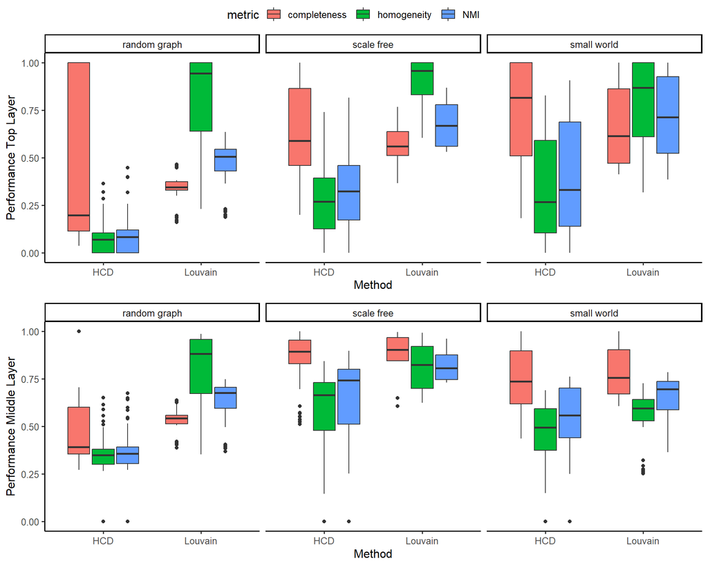

Figure 5.1: Performance of HCD and Louvain methods in predicting the middle and top layer communities for networks in the intermediate networks dataset. Plots are faceted by the subgraph structure. A box and whisker plot is plotted separately for each performance metric: completeness (orange) homogeneity (green) or NMI (blue) and across the two methods.

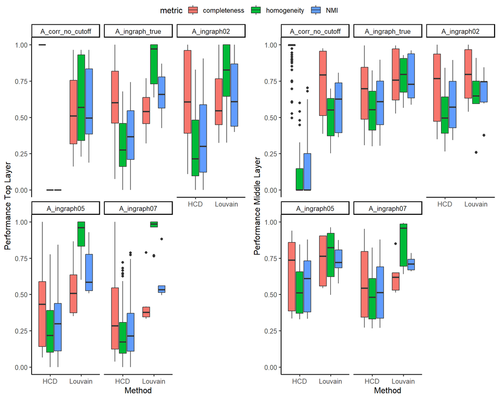

Figure 5.2: Performance of HCD and Louvain methods in predicting the middle and top layer communities for networks in the intermediate networks dataset. Plots are faceted according to the input graphs outlined in Section “Application to Intermediate Networks”. A box and whisker plot is plotted separately for each performance metric: completeness (orange) homogeneity (green) or NMI (blue) and across the two methods.

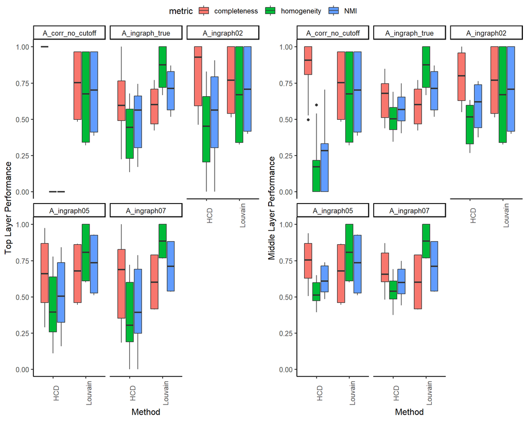

Figure 5.3: Performance of HCD and Louvain methods in predicting the middle and top layer communities. Results are shown for only intermediate networks generated under the small world architectures. Plots are faceted according to the input graphs outlined in Section “Application to Intermediate Networks”. A box and whisker plot is plotted separately for each performance metric: completeness (orange) homogeneity (green) or NMI (blue) and across the two methods.

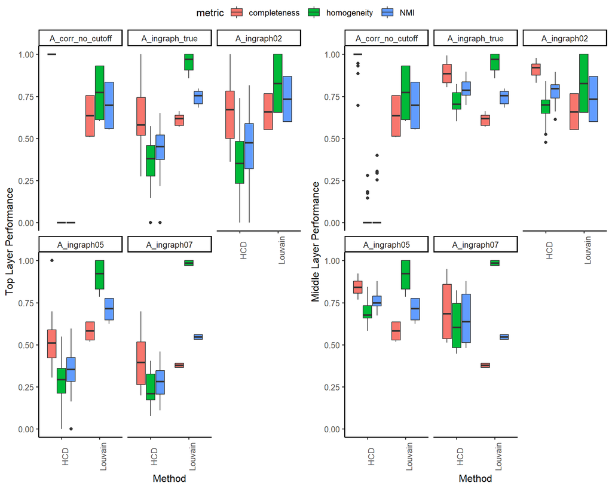

Figure 5.4: Performance of HCD and Louvain methods in predicting the middle and top layer communities. Results are shown for only intermediate networks generated under the scale free architecture. Plots are faceted according to the input graphs outlined in Section “Application to Intermediate Networks”. A box and whisker plot is plotted separately for each performance metric: completeness (orange) homogeneity (green) or NMI (blue) and across the two methods.

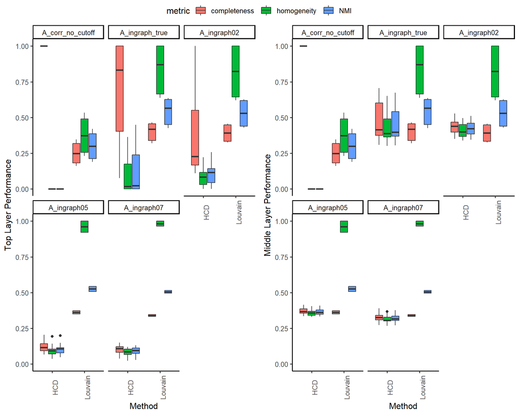

Figure 5.5: Performance of HCD and Louvain methods in predicting the middle and top layer communities. Results are shown for only intermediate networks generated under the random graph architecture. Plots are faceted according to the input graphs outlined in Section “Application to Intermediate Networks”. A box and whisker plot is plotted separately for each performance metric: completeness (orange) homogeneity (green) or NMI (blue) and across the two methods.

[figure not shown]

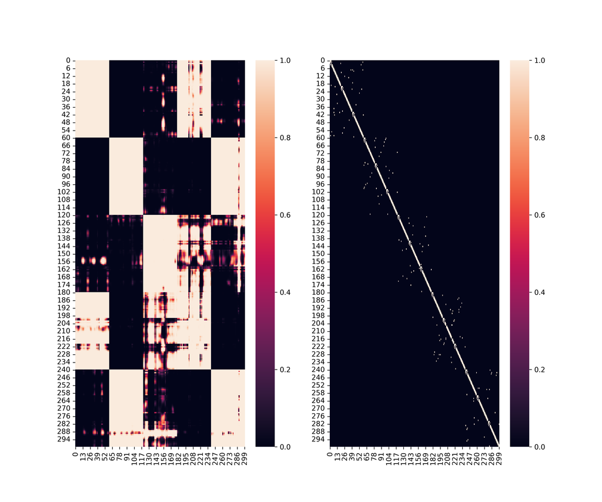

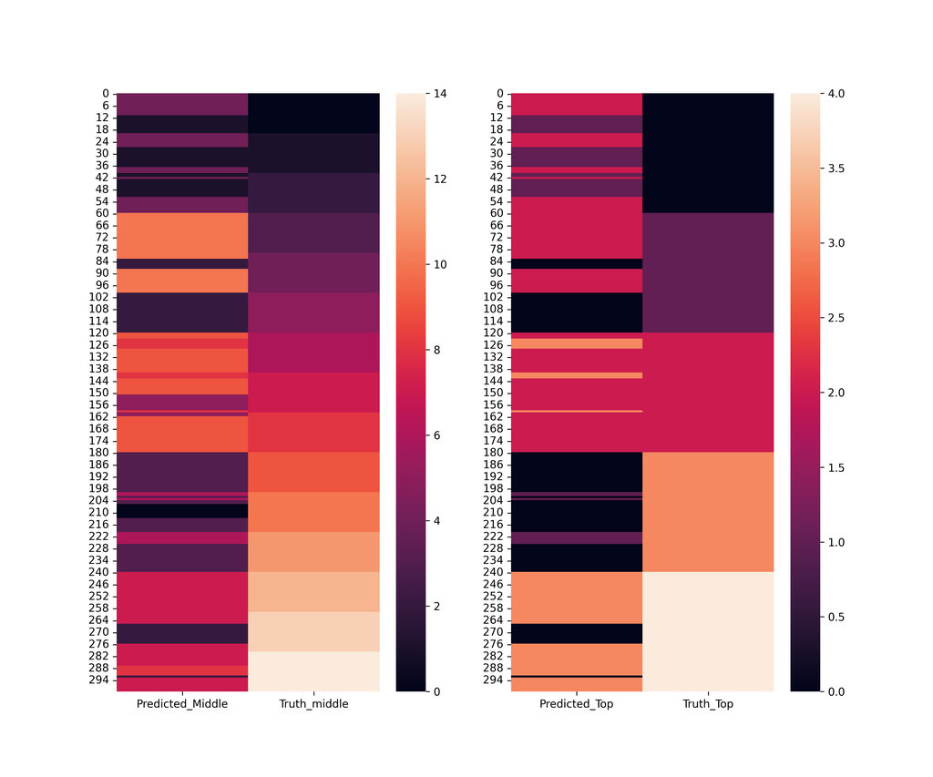

# References

Barabási, Albert-László, and Eric Bonabeau. 2003. “Scale-Free Networks.” *Scientific American* 288 (5): 60–69.

Watts, Duncan J, and Steven H Strogatz. 1998. “Collective Dynamics of ‘Small-World’networks.” *Nature* 393 (6684): 440–42.